# Modulo 5 · Visualizacion de datos

Un buen BI no solo calcula numeros, los **comunica** de forma clara. En este modulo aprenderas a construir los graficos mas usados en reportes de negocio con tres librerias:

- **matplotlib**: la base de la visualizacion en Python, maximo control.
- **seaborn**: graficos estadisticos con mejor estetica por defecto.
- **plotly**: graficos interactivos, ideales para dashboards.

**Contenidos:**

1. Grafico de lineas: tendencia de ingresos en el tiempo
2. Grafico de barras: ranking de productos/regiones
3. Grafico de torta / dona: participacion por categoria
4. Histograma y boxplot: distribucion del ticket de venta
5. Heatmap: ventas por region y categoria
6. Version interactiva con Plotly

```python
import pandas as pd
import matplotlib.pyplot as plt
import seaborn as sns
import plotly.io as pio

pio.renderers.default = "notebook_connected"
sns.set_theme(style="whitegrid")
plt.rcParams["figure.figsize"] = (10, 5)

df = pd.read_csv("../data/ventas_limpio.csv", parse_dates=["fecha"])
df["periodo"] = df["fecha"].dt.to_period("M").astype(str)
df.head()
```

|  | id_venta | fecha | region | categoria | producto | vendedor | segmento_cliente | unidades | precio_unitario | descuento_pct | ingreso | costo | utilidad | anio | mes | nombre_mes | dia_semana | trimestre | margen_pct | periodo |
| --- | --- | --- | --- | --- | --- | --- | --- | --- | --- | --- | --- | --- | --- | --- | --- | --- | --- | --- | --- | --- |
| 0 | 1 | 2023-01-01 | Este | Deportes | Bicicleta | Hugo Reyes | Pyme | 5 | 166190.0 | 0.20 | 664760.0 | 498570.0 | 166190.0 | 2023 | 1 | January | Sunday | 1 | 0.2500 | 2023-01 |
| 1 | 2 | 2023-01-01 | Sur | Electronica | Parlante Bluetooth | Bruno Silva | Individual | 2 | 25420.0 | 0.00 | 50840.0 | 30504.0 | 20336.0 | 2023 | 1 | January | Sunday | 1 | 0.4000 | 2023-01 |
| 2 | 3 | 2023-01-01 | Este | Hogar | Aspiradora | Gabriela Nunez | Pyme | 6 | 80310.0 | 0.15 | 409581.0 | 289116.0 | 120465.0 | 2023 | 1 | January | Sunday | 1 | 0.2941 | 2023-01 |
| 3 | 4 | 2023-01-01 | Sur | Hogar | Aspiradora | Hugo Reyes | Pyme | 5 | 77630.0 | 0.00 | 388150.0 | 232890.0 | 155260.0 | 2023 | 1 | January | Sunday | 1 | 0.4000 | 2023-01 |
| 4 | 5 | 2023-01-01 | Sur | Oficina | Escritorio | Diego Rojas | Individual | 6 | 97620.0 | 0.00 | 585720.0 | 351432.0 | 234288.0 | 2023 | 1 | January | Sunday | 1 | 0.4000 | 2023-01 |

## 1. Grafico de lineas: tendencia de ingresos

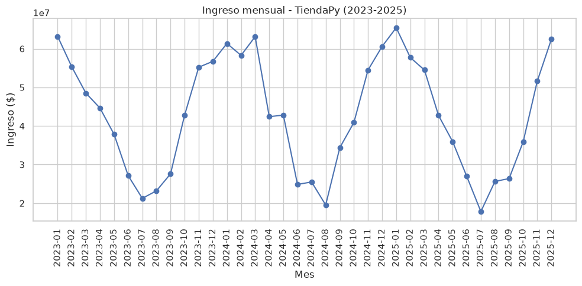

```python
ingreso_mensual = df.groupby("periodo")["ingreso"].sum()

fig, ax = plt.subplots()
ax.plot(ingreso_mensual.index, ingreso_mensual.values, marker="o", color="#4C72B0")
ax.set_title("Ingreso mensual - TiendaPy (2023-2025)")
ax.set_xlabel("Mes")
ax.set_ylabel("Ingreso ($)")
ax.tick_params(axis="x", rotation=90)
plt.tight_layout()
plt.show()
```

## 2. Grafico de barras: ranking de productos

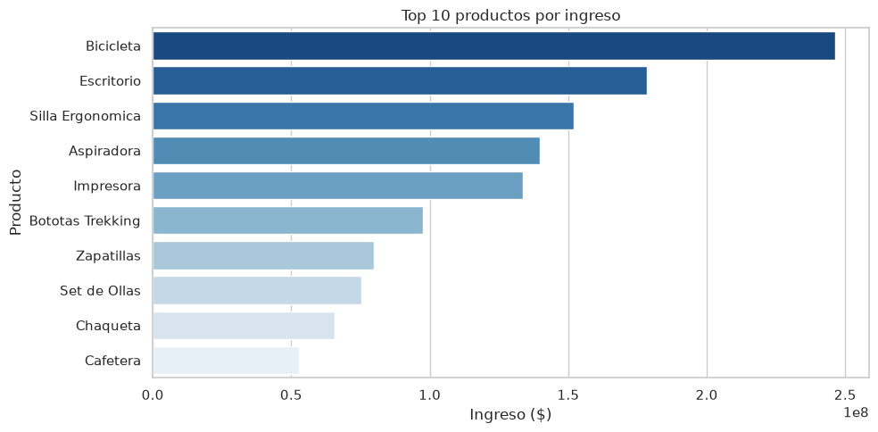

```python
top_productos = df.groupby("producto")["ingreso"].sum().sort_values(ascending=False).head(10)

fig, ax = plt.subplots()
sns.barplot(x=top_productos.values, y=top_productos.index, hue=top_productos.index, palette="Blues_r", legend=False, ax=ax)
ax.set_title("Top 10 productos por ingreso")
ax.set_xlabel("Ingreso ($)")
ax.set_ylabel("Producto")
plt.tight_layout()
plt.show()
```

## 3. Grafico de torta / dona: participacion por categoria

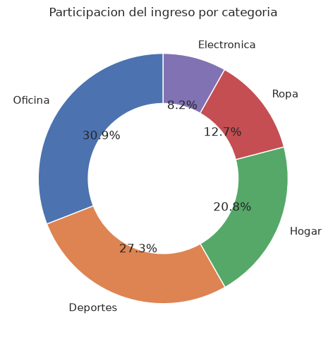

```python
participacion = df.groupby("categoria")["ingreso"].sum().sort_values(ascending=False)

fig, ax = plt.subplots()
ax.pie(
    participacion.values,
    labels=participacion.index,
    autopct="%1.1f%%",
    startangle=90,
    wedgeprops={"width": 0.4},  # esto lo convierte en dona
)
ax.set_title("Participacion del ingreso por categoria")
plt.tight_layout()
plt.show()
```

## 4. Histograma y boxplot: distribucion del ticket de venta

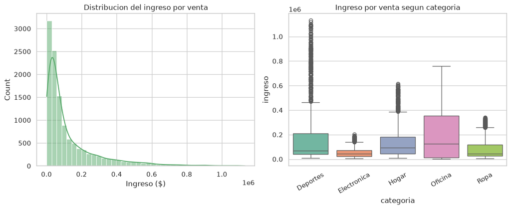

```python
fig, axes = plt.subplots(1, 2, figsize=(12, 5))

sns.histplot(df["ingreso"], bins=40, kde=True, ax=axes[0], color="#55A868")
axes[0].set_title("Distribucion del ingreso por venta")
axes[0].set_xlabel("Ingreso ($)")

sns.boxplot(x="categoria", y="ingreso", hue="categoria", data=df, ax=axes[1], palette="Set2", legend=False)
axes[1].set_title("Ingreso por venta segun categoria")
axes[1].tick_params(axis="x", rotation=30)

plt.tight_layout()
plt.show()
```

## 5. Heatmap: ventas por region y categoria

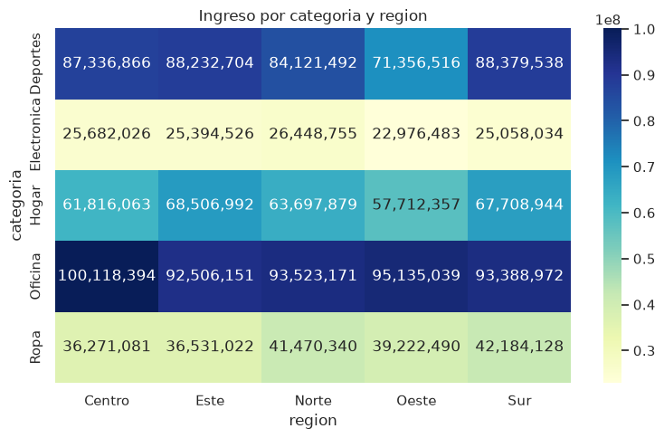

```python
tabla = df.pivot_table(values="ingreso", index="categoria", columns="region", aggfunc="sum")

fig, ax = plt.subplots(figsize=(8, 5))
sns.heatmap(tabla, annot=True, fmt=",.0f", cmap="YlGnBu", ax=ax)
ax.set_title("Ingreso por categoria y region")
plt.tight_layout()
plt.show()
```

## 6. Version interactiva con Plotly

Plotly genera graficos interactivos (zoom, tooltips, filtros) ideales para un dashboard. Es la libreria que usaremos en el modulo de Streamlit.

```python
import plotly.express as px

ingreso_mensual_df = df.groupby("periodo", as_index=False)["ingreso"].sum()

fig = px.line(
    ingreso_mensual_df,
    x="periodo",
    y="ingreso",
    markers=True,
    title="Ingreso mensual (interactivo)",
    labels={"periodo": "Mes", "ingreso": "Ingreso ($)"},
)
fig.update_layout(xaxis_tickangle=-90)
fig.show()
```

[interactive chart not shown]

```python
top_10 = df.groupby("producto", as_index=False)["ingreso"].sum().sort_values("ingreso", ascending=False).head(10)

fig = px.bar(
    top_10,
    x="ingreso",
    y="producto",
    orientation="h",
    title="Top 10 productos por ingreso (interactivo)",
    color="ingreso",
    color_continuous_scale="Blues",
)
fig.update_layout(yaxis={"categoryorder": "total ascending"})
fig.show()
```

[interactive chart not shown]

## 🧠 Retos del modulo 5

1. Crea un grafico de barras con el ingreso total por region (usa matplotlib o seaborn).
2. Crea un grafico de lineas que muestre la evolucion mensual del **margen promedio** (no del ingreso).
3. Con Plotly, crea un grafico de dispersion (`px.scatter`) que compare `unidades` vs `ingreso`, coloreado por `categoria`.
4. Crea un heatmap de ingreso por `dia_semana` (columna `df["fecha"].dt.day_name()`) y `categoria`. ¿Que patrones observas?

Compara tus resultados con `solutions/05_visualizacion_solucion.py`.

```python
# Escribe aqui tu solucion
```